[OHI-Northeast](http://www.ohi-northeast.org/) | [OHI Science](http://ohi-science.org) | [Citation policy](http://ohi-science.org/citation-policy/)

# Coastal condition assessment data layers

Compiled on Tue Aug 7 10:05:36 2018 by afflerbach

## Summary

```r
knitr::opts_chunk$set(fig.width = 10, fig.height = 6, fig.path = 'figs/', message = FALSE, warning = FALSE)

source('~/github/ne-prep/src/R/common.R')

library(tidyverse)
```

## Load Water Quality Index data

There are two Water Quality Index datasets we are going to use for the two different time periods. I want to select only the information I need.

```r
water_old <- readxl::read_excel(file.path(dir_anx, "_raw_data/EPA/nca_waterchemdata_narschallenge.xlsx")) %>%
  filter(PSTL_CODE %in% c("MA", "ME", "RI", "NY", "NH", "CT")) %>%
  select(SITE_ID, status = Cat_WQI, LON_DD, LAT_DD, PSTL_CODE, Year = SAMPYEAR)

water_new <- read_csv(file.path(dir_anx, "_raw_data/EPA/ncca2010_water_quality_indicator_status.csv")) %>%
  filter(PSTL_CODE %in% c("MA", "ME", "RI", "NY", "NH", "CT"),
         NCCA_REG == "Northeast") %>%
  select(SITE_ID, status = CAT_WQI, LON_DD, LAT_DD, PSTL_CODE) %>%
  mutate(Year = 2010)
```

## Data wrangling

Combining both datasets and assigning hte time periods for each. If the year is 2000 or 2001, that’s time period 1. 2005-2006 is time period 2 and 2010 is time period 3.

```r
wqi <- water_old %>%
  bind_rows(water_new) %>%
  mutate(time_period =
           case_when(
             Year %in% c(2000, 2001) ~ 1,
             Year %in% c(2005, 2006) ~ 2,
             Year == 2010 ~ 3
           ))
```

I also need to assign regions to each of these. For the most part, the State is the region but for Massachusetts we need to be specific to what region it belongs. The best way to do this is manually.

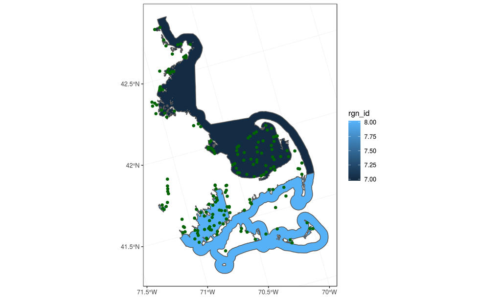

```r
ma <- wqi %>%
  filter(PSTL_CODE == "MA")

ma_points = st_as_sf(ma, coords = c("LON_DD", "LAT_DD"),
                 crs = 4326)

mapview::mapview(ma_points)

ggplot() +
  geom_sf(data = rgns %>% filter(rgn_id %in% c(7,8)), aes(fill = rgn_id)) +
  geom_sf(data = ma_points, color = 'darkgreen') +
  theme_bw()
```

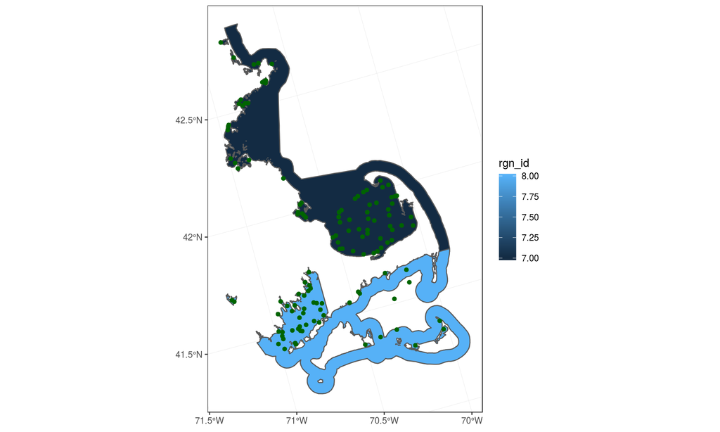

```r
#try an st_intersect

int <- ma_points %>%
  st_transform('+proj=aea +lat_1=29.5 +lat_2=45.5 +lat_0=37.5 +lon_0=-96 +x_0=0 +y_0=0 +ellps=GRS80 +units=m +no_defs') %>%
  st_intersection(rgns)

ggplot() +
  geom_sf(data = rgns %>% filter(rgn_id %in% c(7,8)), aes(fill = rgn_id)) +
  geom_sf(data = int, color = 'darkgreen') +
  theme_bw()
```

```r
mapview::mapview(int)

# what points are we missing

s <- setdiff(ma_points$SITE_ID, int$SITE_ID)

miss <- ma_points %>%
  filter(SITE_ID %in% s)

mapview::mapview(miss)

#add a rgn_id column manually for the missing points based on mapview
miss_gf <- miss %>%
  data.frame() %>%
  mutate(rgn_id =
           case_when(
             SITE_ID == "MA01-0080" ~ 7,
             SITE_ID == "MA01-0076" ~ 7,
             SITE_ID == "MA00-0075" ~ 7,
             SITE_ID == "MA01-0004" ~ 7,
             SITE_ID == "MA00-0075" ~ 7,
             SITE_ID == "MA01-0074" ~ 7,
             SITE_ID == "MA00-0075" ~ 7,
             SITE_ID == "NCCA10-1023" ~ 7,
             SITE_ID == "MA01-0072" ~ 7,
             SITE_ID == "MA00-0075" ~ 7,
             SITE_ID == "MA05-0006" ~ 7,
             SITE_ID == "MA00-0075" ~ 7,
             SITE_ID == "MA00-0071" ~ 7,
             SITE_ID == "MA01-0068" ~ 7,
             SITE_ID == "MA01-0066" ~ 7,
             SITE_ID == "MA00-0067" ~ 7,
             SITE_ID == "MA06-0048" ~ 7,
             SITE_ID == "MA00-0013" ~ 7,
             SITE_ID == "MA00-0065" ~ 7,
             SITE_ID == "MA01-0064" ~ 7,
             SITE_ID == "MA00-0063" ~ 7,
             SITE_ID == "MA01-0062" ~ 7,
             SITE_ID == "MA06-0026" ~ 8,
             SITE_ID == "MA00-0061" ~ 8,
             SITE_ID == "MA00-0059" ~ 8,
             SITE_ID == "BU01-0013" ~ 8,
             SITE_ID == "MA01-0034" ~ 8,
             SITE_ID == "NCCA10-1009" ~ 8,
             SITE_ID == "MA06-0042" ~ 8,
             SITE_ID == "NCCA10-1011" ~ 8,
             SITE_ID == "BU01-0001" ~ 8,
             SITE_ID == "MA01-0046" ~ 8,
             SITE_ID == "MA05-0009" ~ 8,
             SITE_ID == "MA01-0048" ~ 8,
             SITE_ID == "MA01-0010" ~ 8,
             SITE_ID == "MA00-0009" ~ 8,
             SITE_ID == "BU01-0002" ~ 8,
             SITE_ID == "NCCA10-1001" ~ 8,
             SITE_ID == "MA01-0056" ~ 8,
             SITE_ID == "MA00-0055" ~ 8,
             SITE_ID == "NCCA10-1058" ~ 8,
             SITE_ID == "MA01-0050" ~ 8,
             SITE_ID == "MA00-0049" ~ 8,
             SITE_ID == "MA01-0054" ~ 8,
             SITE_ID == "NCCA10-1008" ~ 8,
             SITE_ID == "BU01-0016" ~ 8,
             SITE_ID == "MA00-0039" ~ 8,
             SITE_ID == "MA00-0035" ~ 8,
             SITE_ID == "NCCA10-2001" ~ 8,
             SITE_ID == "MA01-0090" ~ 8,
             SITE_ID == "MA00-0089" ~ 8,
             SITE_ID == "MA00-0087" ~ 8,
             SITE_ID == "MA01-0088" ~ 8,
             SITE_ID == "MA00-0085" ~ 8,
             SITE_ID == "MA00-0083" ~ 8,
             SITE_ID == "RI05-0025" ~ 8,
             SITE_ID == "MA01-0084" ~ 8
           )) %>%
  select(-geometry)

# take the info from int that we want and combine with these missing sites

ma_df <- int %>%
  data.frame() %>%
  select(-area_km2, -geometry, -rgn_name) %>%
  bind_rows(miss_gf)
```

```r
wqi_clean <- wqi %>%
  mutate(rgn_name =
           case_when(
             PSTL_CODE == "ME" ~ "Maine",
             PSTL_CODE == "RI" ~ "Rhode Island",
             PSTL_CODE == "NY" ~ "New York",
             PSTL_CODE == "CT" ~ "Connecticut",
             PSTL_CODE == "NH" ~ "New Hampshire",
             PSTL_CODE == "MA" ~ "NA"
           )) %>%
  left_join(rgn_data) %>%
  left_join(ma_df, by = c("SITE_ID", "time_period", "Year", "status", "PSTL_CODE")) %>%
  mutate(rgn_id = ifelse(is.na(rgn_id.x), rgn_id.y, rgn_id.x)) %>%
  select(-rgn_id.x, -rgn_id.y, -rgn_name, -state, -area_km2) %>%
  left_join(rgn_data) %>%
  select(-area_km2) %>%
  mutate(score =
      case_when(
        status == "POOR" ~ 0,
        status == "FAIR" ~ 50,
        status == "GOOD" ~ 100
      )
  ) %>%
  filter(!is.na(score),
         rgn_name != "Georges Bank")
  # mutate(rgn_name = ifelse(rgn_id == 2, "Massachusetts-Virginian", rgn_name),  ### added this in if we want to turn GB sites to MA
  #        state = ifelse(rgn_id == 2, NA, state),
  #        rgn_id = ifelse(rgn_id == 2, 8, rgn_id))
```

Aggregate by region and take average

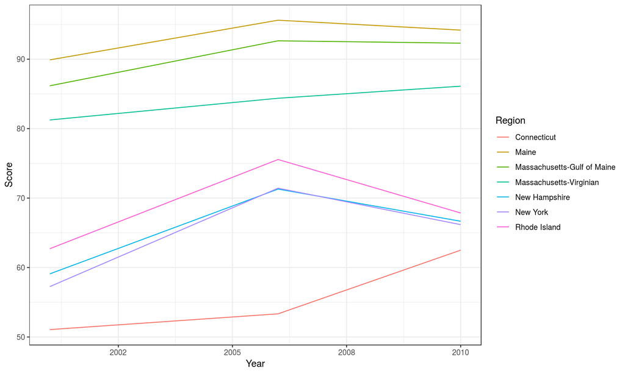

```r
wqi_rgns <- wqi_clean %>%
  group_by(rgn_id, rgn_name, time_period) %>%
  summarize(score = mean(score, na.rm=T)) %>%
  mutate(year =
           case_when(
             time_period == 1 ~ 2001,
             time_period == 2 ~ 2006,
             time_period == 3 ~ 2010
           ))

ggplot(wqi_rgns, aes(x = year, y = score, color = rgn_name)) +
  geom_line() +
  theme_bw() +
  labs(x = "Year",
       y = "Score",
       color = "Region")
```

## Gap-filling

The plot has guessed the values between 2001, 2006 and 2010 but we need to actually assign these before saving this layer. We will assume a simple linear interpolation between years.

```r
df_gf <- wqi_rgns %>%
  select(-time_period) %>%
  complete(year = 2001:2010) %>%
  group_by(rgn_name, rgn_id) %>%
  mutate(score = zoo::na.approx(score))
```

## Save layer for toolbox

```r
other_rgns <- data.frame(year     = rep(2001:2010, each = 4),
                         rgn_id   = c(1,2,3,4),
                         rgn_name = c("Offshore", "Georges Bank", "Gulf of Maine", "Mid-Atlantic Bight"),
                         score = NA)

out <- df_gf %>%
  bind_rows(other_rgns) %>%
  write_csv(file.path(dir_calc, "layers/cw_wqi.csv"))
```

## Citation

Citation: U.S. Environmental Protection Agency. 2016. National Aquatic Resource Surveys. National Coastal Condition Assessment 2010 (data and metadata files). Available from U.S. EPA web page:https://www.epa.gov/national-aquatic-resource-surveys/data-national-aquatic-resource-surveys. Data from the National Aquatic Resource Surveys. Date accessed: 2018-07-31.